# Discrimination

Author

David Kane

```
 Family: bernoulli
  Links: mu = logit
Formula: call ~ race
   Data: x (Number of observations: 4870)
  Draws: 4 chains, each with iter = 2000; warmup = 1000; thin = 1;
         total post-warmup draws = 4000

Regression Coefficients:
          Estimate Est.Error l-95% CI u-95% CI Rhat Bulk_ESS Tail_ESS
Intercept    -2.68      0.08    -2.84    -2.52 1.00     2176     2208
racewhite     0.44      0.11     0.23     0.65 1.00     2548     2463

Draws were sampled using sampling(NUTS). For each parameter, Bulk_ESS
and Tail_ESS are effective sample size measures, and Rhat is the potential
scale reduction factor on split chains (at convergence, Rhat = 1).
```

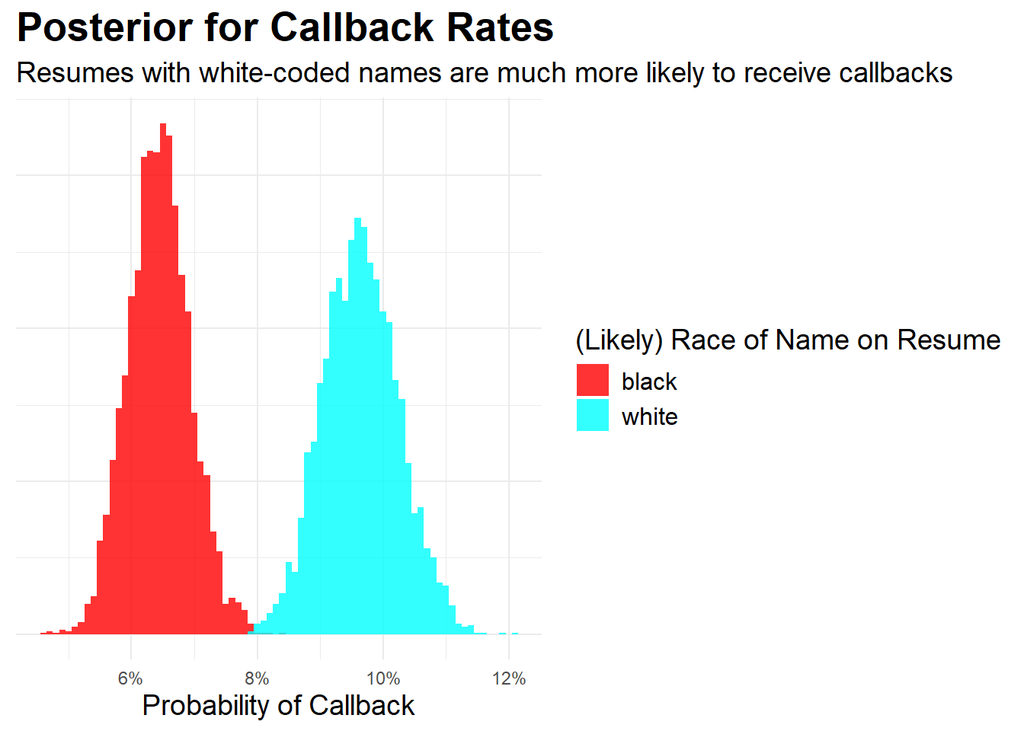

## From Monday’s Class

### Background Information

Bertrand, Marianne and Sendhil Mullainathan. 2004. “Are Emily and Greg More Employable Than Lakisha and Jamal? A Field Experiment on Labor Market Discrimination.” American Economic Review, 94 (4): 991–1013. Data cleaned and discussed in “Quantitative Social Science: An Introduction” by Kosuke Imai.

“We study race in the labor market by sending fictitious resumes to help-wanted ads in Boston and Chicago newspapers. To manipulate perceived race, resumes are randomly assigned African-American- or White-sounding names. White names receive 50 percent more callbacks for interviews. Callbacks are also more respon- sive to resume quality for White names than for African-American ones. The racial gap is uniform across occupation, industry, and employer size. We also find little evidence that employers are inferring social class from the names. Differential treatment by race still appears to still be prominent in the U.S. labor market.”

### Discussion

Subject: Discrimination

Broad question: Race and employment in the United States

Specific question: Effect of racially-coded names on call-backs in 2020’s for adults in Boston and Chicago applying for jobs.

Preceptor Table:

- Units: individuals (or resumes ?)
- (Potential) Outcomes: call-back if black name, call-back if white name
- Causal/predictive: a causal model
- Covariates: sex, zip code (not shown in table)
- Treatment: black name on resume versus white name on resume

## Example Preceptor Table

Preceptor Table

| ID | Potential Outcomes Callback if White Name | Potential Outcomes Callback if Black Name | Covariate Treatment |
| --- | --- | --- | --- |
| 1 | Yes* | Yes | Black |
| 2 | No | Yes* | White |
| … | … | … | … |
| 10 | No* | No | Black |
| 11 | Yes* | Yes | Black |
| … | … | … | … |
| N | Yes | No* | White |

## Questions for Second Class

> What are the units, precisely?

All the people sending out resumes for entry-level positions in Boston and Chicago during 2020 – 2030 who have names which are associated with a race. So, N is (?) in the thousands.

> What is the moment in time, precisely?

2020 to 2030

> What is one reason why validity might not hold?

There is less of a strong connection between names and race.

> Describe the Population Table in words

Every time a person with a racially-coded name sends out a resume in Boston/Chicago between 2000 and 2030.

> What is one reason why stability might not hold?

> What is one reason why representativeness might not hold?

> What is one reason why unconfoundedness might not hold?

> Describe in words what the Preceptor Table would look like if we were trying to, instead, predict whether or not someone would get a callback?

Preceptor Table

| ID | Outcome Callback | Covariate Treatment |
| --- | --- | --- |
| 1 | Yes | Black |
| 2 | No | White |
| … | … | … |
| 10 | No | Black |
| 11 | Yes | Black |
| … | … | … |
| N | Yes | White |